# Model Interpretability

Jeremiah W

December 2020

# Resources

- [Vid](https://youtu.be/eNvKnhMJd2o)
- [DataDic](https://www.kaggle.com/c/house-prices-advanced-regression-techniques/data)
- [IML vignette](https://cran.r-project.org/web/packages/iml/vignettes/intro.html)
- [PFI](https://christophm.github.io/interpretable-ml-book/feature-importance.html#advantages-9)
- [ALE](https://christophm.github.io/interpretable-ml-book/ale.html)
- [LIME](https://christophm.github.io/interpretable-ml-book/lime.html)
- [R txbk](https://bradleyboehmke.github.io/HOML/iml.html)

```r
a = a %>%
  select_if(is.numeric) %>%
  relocate(Sale_Price)
```

```r
lm = lm(Sale_Price ~ . , data = a)
lm %>% tidy
```

```
## # A tibble: 35 x 5
##    term                estimate    std.error statistic  p.value
##    <chr>                  <dbl>        <dbl>     <dbl>    <dbl>
##  1 (Intercept)    -11429773.    3528553.        -3.24  1.21e- 3
##  2 Lot_Frontage          87.4        21.0        4.16  3.26e- 5
##  3 Lot_Area               0.314       0.0930     3.38  7.37e- 4
##  4 Year_Built           385.         39.2        9.82  1.99e-22
##  5 Year_Remod_Add       513.         43.8       11.7   4.92e-31
##  6 Mas_Vnr_Area          37.9         4.39       8.64  9.12e-18
##  7 BsmtFin_SF_1         300.        397.         0.756 4.50e- 1
##  8 BsmtFin_SF_2         -13.4         4.21      -3.18  1.51e- 3
##  9 Bsmt_Unf_SF          -13.4         2.67      -5.01  5.64e- 7
## 10 Total_Bsmt_SF         37.6         3.30      11.4   1.69e-29
## # ... with 25 more rows
```

#Regression w/effect plots

### problem: ‘coef/estimate plots’

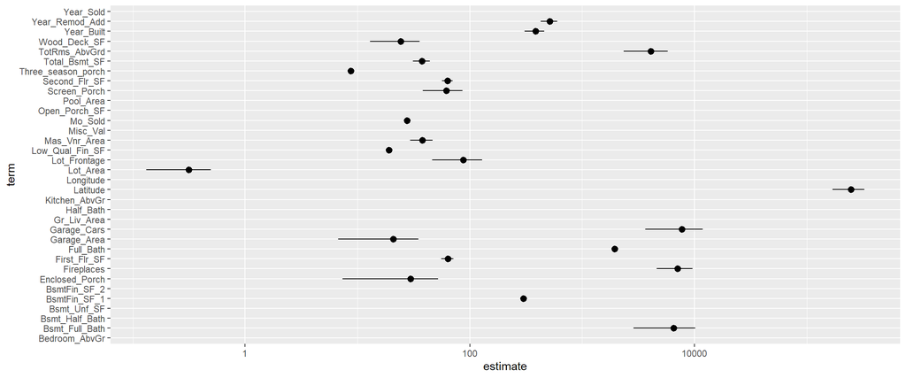

```r
#coef plot w/confi intervals
lm %>% tidy(conf.int = TRUE) %>%  #AWESOME, can get conf intervals w/this arg
  .[-1,] %>%
  ggplot(aes(x = term, y = estimate)) +
  geom_point() +
  geom_pointrange(aes(ymin = conf.low, ymax = conf.high)) +
  coord_flip() +
  scale_y_log10()
```

the problem with this plot is that the features are not in the same units of measure/scales

e.g. LotFrontage: Linear FEET of street connected to property FullBath: COUNT Full bathrooms above grade

### solution: ‘effects plot’

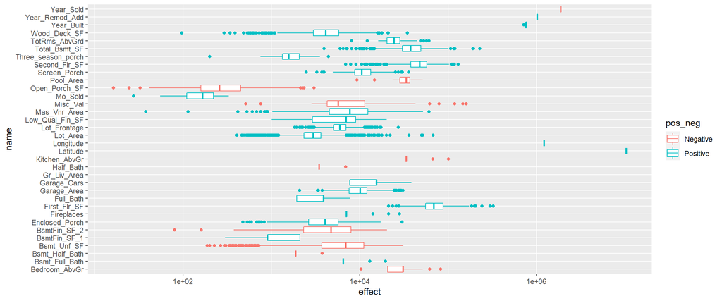

```r
#multiple coefs by actual values to see *contribution*
a %>% mutate(pk = row_number()) %>%
  pivot_longer(cols = c(everything(), -Sale_Price, -pk)) %>% left_join(
    lm %>% tidy %>%
    slice(-1)  %>%  #don't need intercept since it's a constant
    select(term, estimate),
    by = c('name' = 'term')
  ) %>% mutate(
    effect = value * estimate,
    pos_neg = if_else(effect < 0, 'Negative', 'Positive'),
    effect = abs(effect)
  ) %>% ggplot(aes(name, effect, color = pos_neg)) +
  geom_boxplot() + coord_flip() +
  scale_y_log10()
```

# Model Agnostic Methods

### 1 Create and Fit Models

```r
### tidymodels:spec models

rf = rand_forest() %>%
  set_mode('regression') %>%
  set_engine('ranger')

xgb = boost_tree() %>%
  set_mode('regression') %>%
  set_engine('xgboost')

### tidymodels:fit models

set.seed(345)
rf = rf %>% fit(Sale_Price ~ ., data = a)
xgb = xgb %>% fit(Sale_Price ~ ., data = a)
```

### 2 Create Predictor Obj Components

[Ref](http://uc-r.github.io/iml-pkg#procedures)

```r
# 1. create a data frame with just the vars/features/x
x.data = a %>% select(-Sale_Price) %>% as.data.frame()

# 2. create vector of the outcome/y
y.data = a$Sale_Price
```

### 3 Create Predictor Obj

```r
# Similar to DALEX and lime, the *Predictor* object holds the (1) model, (2) the features data, and the (3) outcome data

rf.predictor = Predictor$new(rf, data = x.data, y = y.data)

xgb.predictor = Predictor$new(xgb, data = x.data, y = y.data)
```

## PFI: *FeatureImp*

Permutation Feature Importance Plots

The feature importance measure works by calculating the ‘loss’ in performance measure after permuting the feature.

### Create & Viz FeatureImp Obj

[Ref](http://uc-r.github.io/iml-pkg#vip)

```r
(rf.fimp = FeatureImp$new(rf.predictor, loss = 'mae'))
```

```
## Interpretation method:  FeatureImp
## error function: mae
##
## Analysed predictor:
## Prediction task: unknown
##
##
## Analysed data:
## Sampling from data.frame with 2930 rows and 34 columns.
##
## Head of results:
##          feature importance.05 importance importance.95 permutation.error
## 1    Gr_Liv_Area      2.521649   2.532580      2.554346          18747.92
## 2     Year_Built      2.200936   2.215657      2.240974          16401.84
## 3  Total_Bsmt_SF      2.056779   2.080651      2.118613          15402.43
## 4   First_Flr_SF      1.846320   1.859322      1.881779          13764.00
## 5 Year_Remod_Add      1.736804   1.767605      1.776294          13085.04
## 6    Garage_Area      1.655009   1.662206      1.664778          12304.81
```

```r
(xgb.fimp = FeatureImp$new(xgb.predictor, loss = 'mae'))
```

```
## Interpretation method:  FeatureImp
## error function: mae
##
## Analysed predictor:
## Prediction task: unknown
##
##
## Analysed data:
## Sampling from data.frame with 2930 rows and 34 columns.
##
## Head of results:
##          feature importance.05 importance importance.95 permutation.error
## 1    Gr_Liv_Area      2.556917   2.585626      2.658037          27487.91
## 2  Total_Bsmt_SF      1.935063   1.953738      1.963349          20770.28
## 3    Garage_Cars      1.733161   1.764679      1.810299          18760.38
## 4     Year_Built      1.753639   1.762127      1.810056          18733.25
## 5 Year_Remod_Add      1.712114   1.734815      1.759018          18442.89
## 6       Lot_Area      1.221024   1.234516      1.243243          13124.20
```

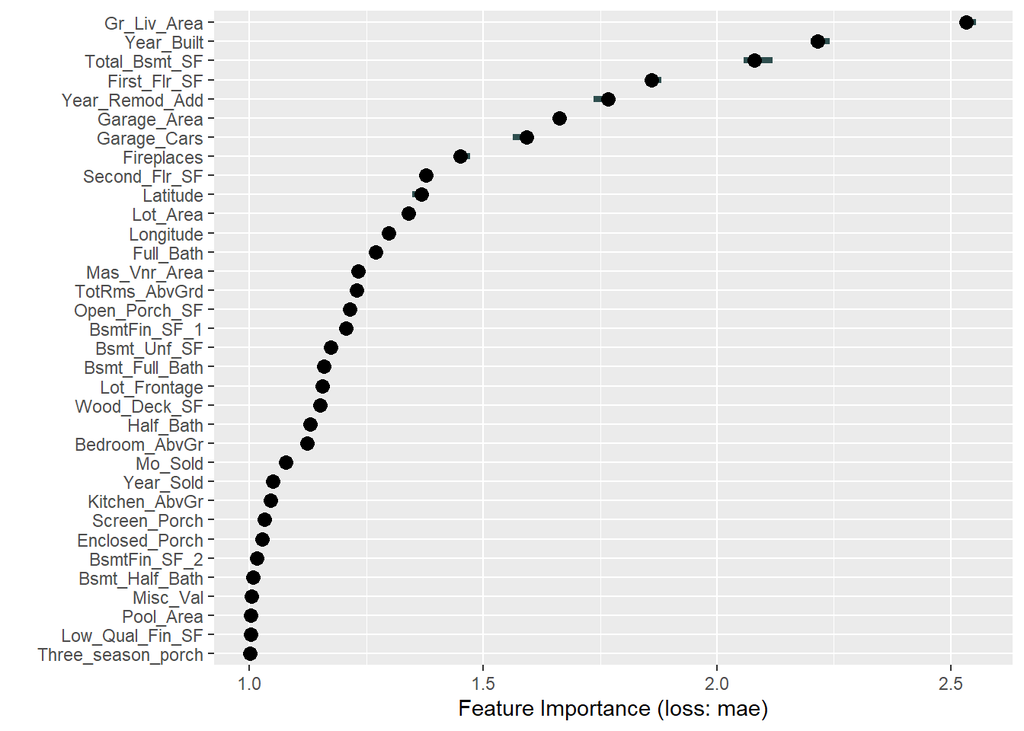

```r
rf.fimp %>% plot
```

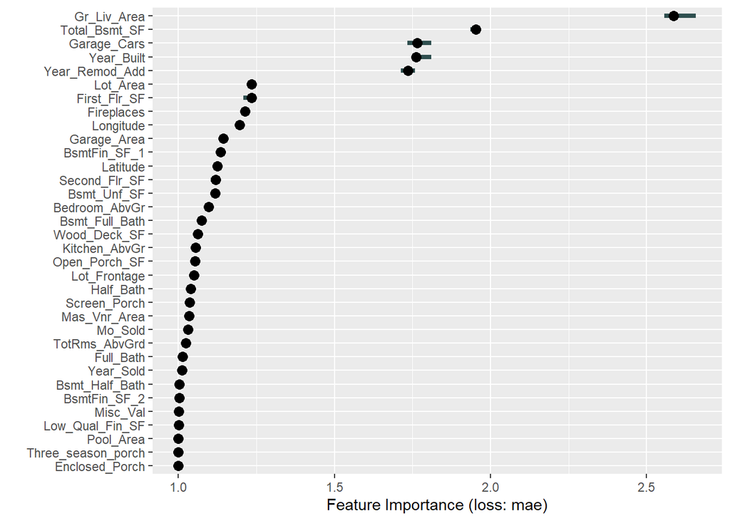

```r
xgb.fimp %>% plot
```

Interpretation: If Gr_Liv_Area is removed, model loses of its predictive power

## ALE: *FeatureEffects*

Accumulated Local Effects

Shows distribution of average effects from each feature

ALE plots are generally ‘better’ than pdp plots since they account for feature correlation. PDP plots assume features are uncorrelated, which is rarely the case IRL (see proof features ARE correleated below)

Predictor > FeatureEffects > plot Predictor > FeatureEffect > plot #NOT plural

### Check: Confirm Feature Correlation

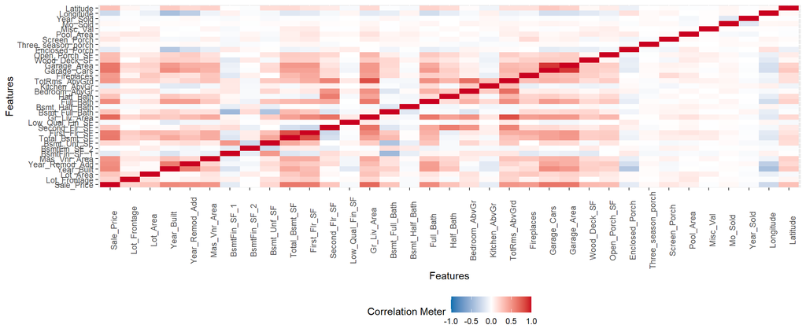

```r
a %>% DataExplorer::plot_correlation()
```

```r
a %>% dlookr::correlate() %>% filter(coef_corr > 0.5 | coef_corr < -0.5) %>% arrange(-coef_corr)
```

```
## # A tibble: 46 x 3
##    var1          var2          coef_corr
##    <fct>         <fct>             <dbl>
##  1 Garage_Area   Garage_Cars       0.890
##  2 Garage_Cars   Garage_Area       0.890
##  3 TotRms_AbvGrd Gr_Liv_Area       0.808
##  4 Gr_Liv_Area   TotRms_AbvGrd     0.808
##  5 First_Flr_SF  Total_Bsmt_SF     0.800
##  6 Total_Bsmt_SF First_Flr_SF      0.800
##  7 Gr_Liv_Area   Sale_Price        0.707
##  8 Sale_Price    Gr_Liv_Area       0.707
##  9 TotRms_AbvGrd Bedroom_AbvGr     0.673
## 10 Bedroom_AbvGr TotRms_AbvGrd     0.673
## # ... with 36 more rows
```

### Create & Plot FeatureEffects object

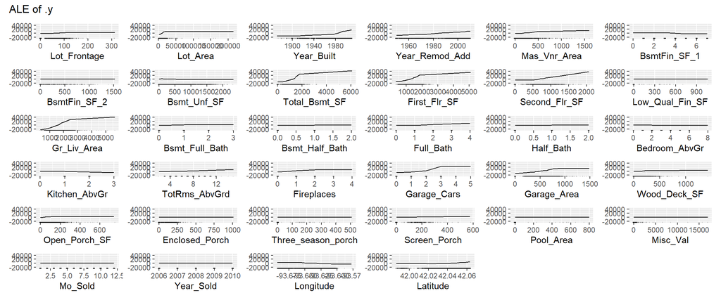

```r
#marginal effect of each feature
rf.ale = FeatureEffects$new(rf.predictor)
xgb.ale = FeatureEffects$new(xgb.predictor)

rf.ale %>% plot
```

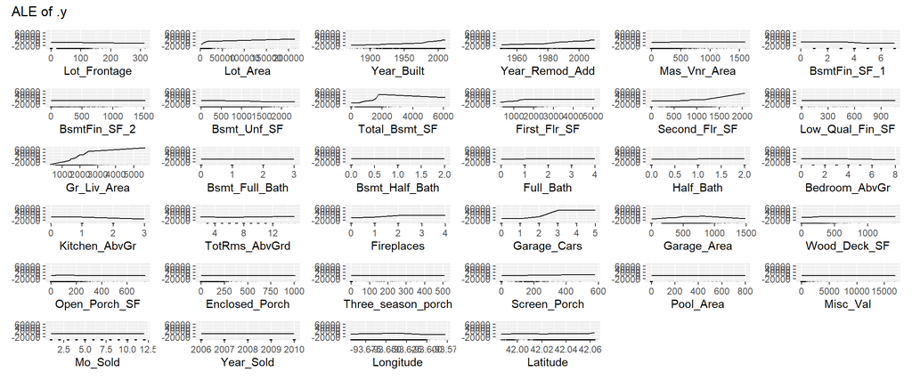

```r
xgb.ale %>% plot
```

[PDP vs ALE](https://christophm.github.io/interpretable-ml-book/ale.html#motivation-and-intuition)

To summarize how each type of plot (PDP, ALE) calculates the effect of a feature at a certain grid value v:  
Partial Dependence Plots: “Let me show you what the model predicts on average when each data instance has the value v for that feature. I *ignore whether the value v makes sense for all data instances*.”  
ALE plots: “Let me show you how the model predictions change in a small”window" of the feature around v *for data instances* in that window."

## *TreeSurrogate* (Global Surrogate Model)

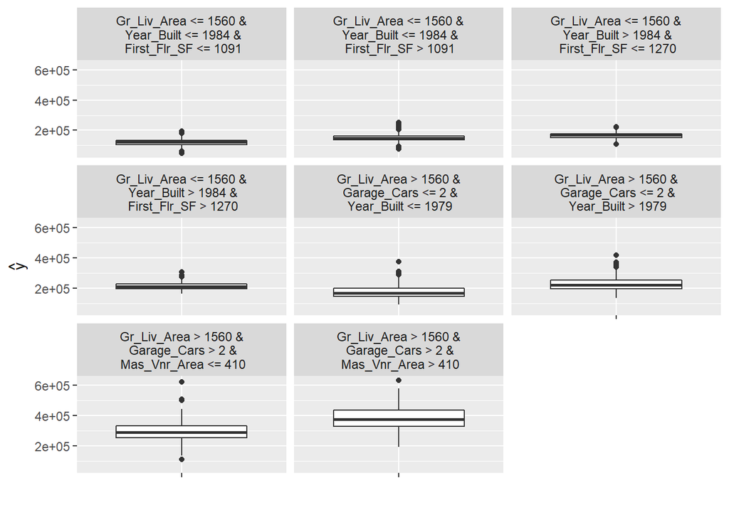

```r
#kidai = 木代

rf.kidai = TreeSurrogate$new(rf.predictor, maxdepth = 3)
xgb.kidai = TreeSurrogate$new(xgb.predictor, maxdepth = 3)

rf.kidai %>% plot
```

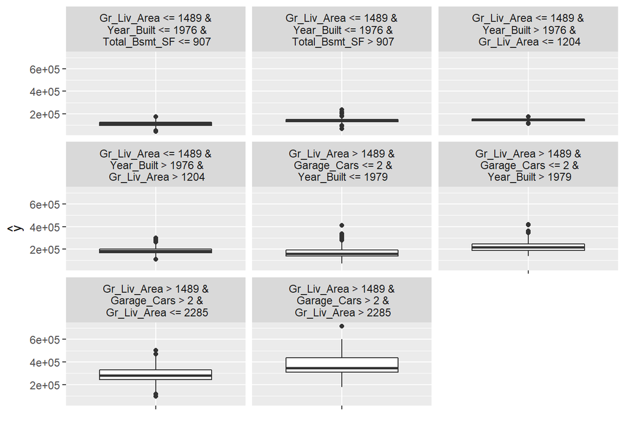

```r
xgb.kidai %>% plot
```

```r
#making predictions using the surrogate model
cbind(
rf.kidai$predict(a) %>% head,
xgb.kidai$predict(a) %>% head
)
```

```
##     .y.hat   .y.hat
## 1 175943.8 170921.8
## 2 119608.2 110381.4
## 3 150792.4 138678.7
## 4 175943.8 170921.8
## 5 227435.7 222187.4
## 6 227435.7 222187.4
```

## LIME *LocalModel* (Local Surrogate Model)

### find the observation with the greatest Gr_Liv_Area

```r
#GrLivArea: Above grade (ground) living area square feet
x.data$Gr_Liv_Area %>% sort(decreasing = TRUE) %>% head(1)
```

```
## [1] 5642
```

```r
x.data %>% mutate(rn = dplyr::row_number(x.data$Gr_Liv_Area)) %>% filter(Gr_Liv_Area == 5642) %>% relocate(rn, Gr_Liv_Area)
```

```
##     rn Gr_Liv_Area Lot_Frontage Lot_Area Year_Built Year_Remod_Add Mas_Vnr_Area
## 1 2930        5642          313    63887       2008           2008          796
##   BsmtFin_SF_1 BsmtFin_SF_2 Bsmt_Unf_SF Total_Bsmt_SF First_Flr_SF
## 1            3            0         466          6110         4692
##   Second_Flr_SF Low_Qual_Fin_SF Bsmt_Full_Bath Bsmt_Half_Bath Full_Bath
## 1           950               0              2              0         2
##   Half_Bath Bedroom_AbvGr Kitchen_AbvGr TotRms_AbvGrd Fireplaces Garage_Cars
## 1         1             3             1            12          3           2
##   Garage_Area Wood_Deck_SF Open_Porch_SF Enclosed_Porch Three_season_porch
## 1        1418          214           292              0                  0
##   Screen_Porch Pool_Area Misc_Val Mo_Sold Year_Sold Longitude Latitude
## 1            0       480        0       1      2008  -93.6749  42.0168
```

### explain the prediction for that observation

```r
(rf.lime = LocalModel$new(rf.predictor, x.interest = x.data[1499,]))
```

```
## Interpretation method:  LocalModel
##
##
## Analysed predictor:
## Prediction task: unknown
##
##
## Analysed data:
## Sampling from data.frame with 2930 rows and 34 columns.
##
## Head of results:
##                      beta x.recoded    effect x.original       feature
## Total_Bsmt_SF    7.284756      6110  44509.86       6110 Total_Bsmt_SF
## Gr_Liv_Area     25.641807      5642 144671.08       5642   Gr_Liv_Area
## Garage_Cars   7396.453803         2  14792.91          2   Garage_Cars
##                    feature.value
## Total_Bsmt_SF Total_Bsmt_SF=6110
## Gr_Liv_Area     Gr_Liv_Area=5642
## Garage_Cars        Garage_Cars=2
```

```r
(xgb.lime = LocalModel$new(xgb.predictor, x.interest = x.data[1499,]))
```

```
## Interpretation method:  LocalModel
##
##
## Analysed predictor:
## Prediction task: unknown
##
##
## Analysed data:
## Sampling from data.frame with 2930 rows and 34 columns.
##
## Head of results:
##                      beta x.recoded    effect x.original       feature
## Total_Bsmt_SF    10.90119      6110  66606.25       6110 Total_Bsmt_SF
## Gr_Liv_Area      29.38682      5642 165800.45       5642   Gr_Liv_Area
## Garage_Cars   10154.84323         2  20309.69          2   Garage_Cars
##                    feature.value
## Total_Bsmt_SF Total_Bsmt_SF=6110
## Gr_Liv_Area     Gr_Liv_Area=5642
## Garage_Cars        Garage_Cars=2
```

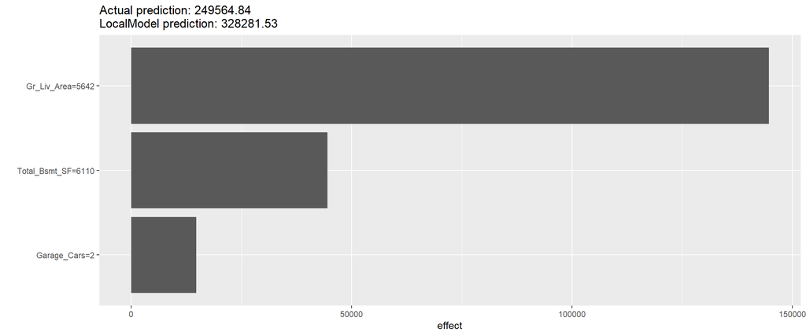

```r
rf.lime %>% plot
```

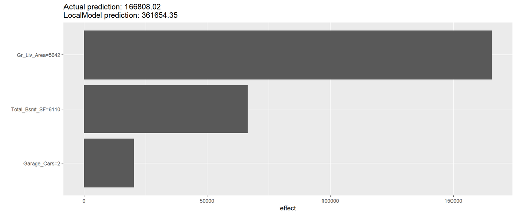

```r
xgb.lime %>% plot
```

## *Interaction*

Warning: Takes ~10m to run

```r
rf.interact = Interaction$new(rf.predictor)
rf.interact %>% plot
```

[output not shown]